# Analyzing the Corpora

Alexey Serdyuk

9 June 2019

This is a part of the capstone project for the cycle of courses [Data Science Specialization](https://www.coursera.org/specializations/jhu-data-science) offered on [Coursera](https://www.coursera.org) by [Johns Hopkins University](https://www.jhu.edu).

We assume that the corpora were already downloaded and preprocessed.

We load the required libraries.

```r
library(data.table) # For fast data tables (extension of data frames).
library(quanteda) # For handling the corpora.
library(readr) # For fast reading/writing.
library(ggplot2) # For charts.
library(ggforce) # For charts.
library(grid) # For arranging charts in a grid.
library(gridExtra) # For arranging charts in a grid.
library(kableExtra) # For formatting tables.
```

We define a function that creates a Corpus from the specified file, where each line is transformed to a separate document.

```r
loadCorpus <- function(fileName) {
    # Read file into a character vector.
    text <- read_lines(fileName)

    # Create a Corpus from the character vector.
    corpus(text)
}
```

Using just defined function, we load pre-processed corpora.

```r
blogs.corpus <- loadCorpus("data-split/blogs.training.pre.txt")
news.corpus <- loadCorpus("data-split/news.training.pre.txt")
twitter.corpus <- loadCorpus("data-split/twitter.training.pre.txt")
```

## Distribution of words

In this section we will study distribution of words in corpora, ignoring for the moment interaction between words (n-grams).

We define two helper functions. The first one creates a Document Feature Matrix (DFM) for words in documents, and aggregates it over all documents to a Feature Vector. The second helper function enriches the Feature Vector with additional values useful for our analysis, such as cumulated coverage of text. We will use the second function later as well, to enrich data on n-grams.

```r
# Calculate Document Feature Matrix (DFM) for words in documents, and aggregate
# it over all documents to a Feature Vector.
build.1gram.fv <- function(text.corpus) {
    text.dfm <- dfm(text.corpus)
    colSums(text.dfm)
}

# Sorts a Feature Vector in descending order of frequency and enriches it with
# additional columns:
#  * Cumulated frequency of terms (words or n-grams)
#  * Cumulated frequency as percentage of total.
enrich.fv <- function(fv) {
    # Transform Feature Vector to a table and sort by frequency descending.
    tbl <- data.table(Terms = names(fv), Freq = fv)
    tbl <- tbl[order(-Freq)]

    # Add columns with cumulative frequency as a number of words, and as percentage.
    tbl$Freq.Cum <- cumsum(tbl$Freq)
    tbl$Freq.Pct <- tbl$Freq.Cum / sum(tbl$Freq)

    return (tbl)
}
```

Now we may calculate frequency of words in each source, as well as in all sources together (aggregated).

```r
blogs.freq <- enrich.fv(build.1gram.fv(blogs.corpus))
news.freq <- enrich.fv(build.1gram.fv(news.corpus))
twitter.freq <- enrich.fv(build.1gram.fv(twitter.corpus))
all.freq <- enrich.fv(build.1gram.fv(blogs.corpus + news.corpus + twitter.corpus))
```

The following chart displays 20 most-frequent words in each source, as well as in the aggregated corpora.

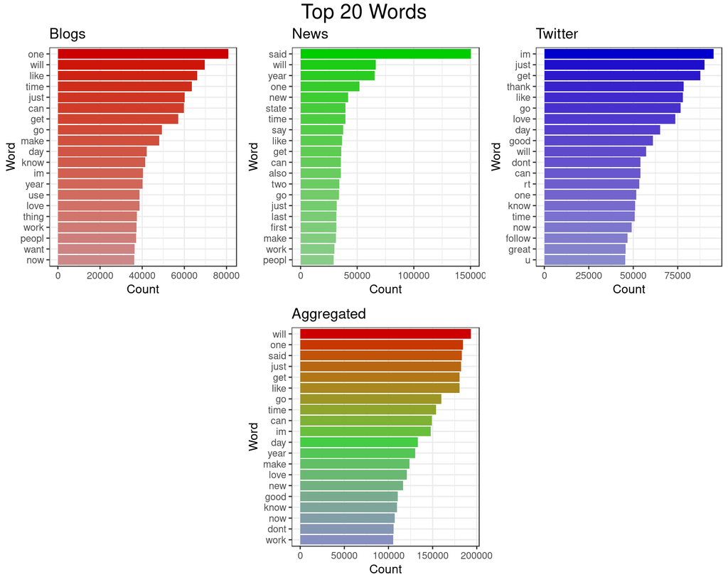

Our next step is to analyze the intersection, that is to find how many words are common to all sources, and how many are unique to a particular source. Not only just a number of words is important, but also a source coverage, that is what percentage of the whole text of a particular source is covered by a particular subset of all words.

The following [Venn diagram](https://en.wikipedia.org/wiki/Venn_diagram) shows a number of unique words (stems) used in each source, as well as a percentage of the aggregated corpora covered by those words.

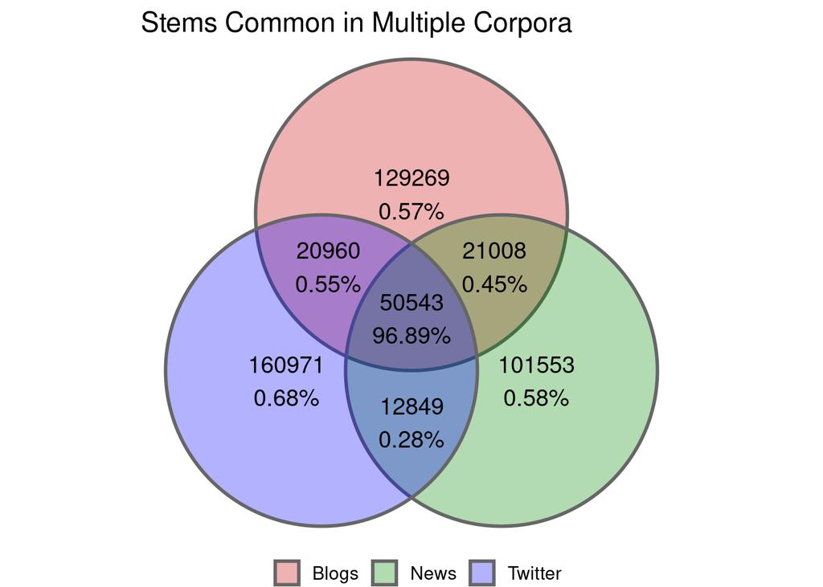

As we may see, 50543 words are shared by all 3 corpora, but those words cover 96.89% of the aggregated corpora. On the other hand, there are 129269 words unique to blogs, but these words appear very infrequently, covering just 0.57% of the aggregated corpora.

The Venn diagram indicates that we may get a high coverage of all corpora by choosing common words. Coverage by words specific to a particular corpus is negligible.

The next step in our analysis is to find out how many common words we should choose to achieve a decent coverage of the text. From the Venn diagram we already know that by choosing 50543 words we will cover 96.89% of the aggregated corpora, but maybe we may reduce a number of words without significantly reducing the coverage.

The following chart shows a number of unique words in each source which cover particular percentage of the text. For example, 1000 most-frequent words cover 68.63% of the Twitter corpus. An interesting observation is that Twitter requires less words to cover particular percentage of the text, whereas news requires more words.

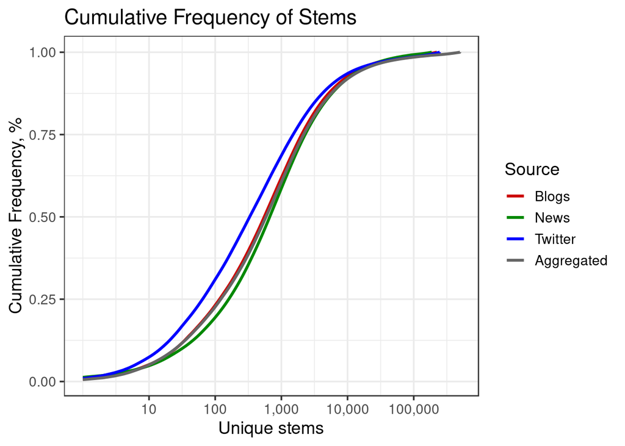

| Corpora Coverage | Blogs | News | Twitter | Aggregated |
| --- | --- | --- | --- | --- |
| 75% | 2023 | 2285 | 1503 | 2165 |
| 90% | 6870 | 7633 | 5602 | 7579 |
| 95% | 15756 | 16951 | 14273 | 18315 |
| 99% | 105360 | 80393 | 142407 | 170904 |
| 99.9% | 210138 | 174174 | 235031 | 463440 |

The table shows that in order to cover 95% of blogs, we require 15756 words. The same coverage of news require 16951 words, and the coverage of twitter 14273 words. To cover 95% of the aggregated corpora, we require 18315 unique words.